# State MSM Profile: **Ohio**

### Background & Methods

In 2015-2016, researchers at Emory University partnered with colleagues at the Centers for Disease Control and Prevention (CDC) to develop methods to estimate the number of men who have sex with men (MSM) residing in each county in the United States. Using population and housing data from the [American Community Survey](https://www.census.gov/programs-surveys/acs/) and estimates from two peer-reviewed publications ([Oster et al., 2015](http://www.ncbi.nlm.nih.gov/pubmed/26115985) & [Purcell et al., 2012](http://www.ncbi.nlm.nih.gov/pubmed/23049658)), they derived an indirect estimate of MSM population sizes that took into account both the urbanicity of the county as well as its density of households with a male householder and a male same-sex partner.

The full methodology is published in the *Journal of Medical Internet Research - Public Health and Surveillance*:

> [Grey JA, Bernstein KT, Sullivan PS, Purcell DW, Chesson HW, Gift TL, Rosenberg ES. Estimating the population sizes of men who have sex with men in US states and counties using data from the American Community Survey. JMIR Public Health Surveill 2016;2(1):e14. DOI: 10.2196/publichealth.5365](http://publichealth.jmir.org/2016/1/e14/)

### Overview of MSM in Ohio

An estimated **144,366** men who have sex with men (MSM) resided in Ohio in 2013, representing 3.2% of the 4,503,084 MSM in the United States. Of the 4,263,691 adult men of Ohio, 3.4% had had sex with another man in the past 5 years, which was less than the overall percentage of adult men in the United States who were MSM (3.9%).

Most MSM in Ohio resided in central counties of large metropolitan areas (50.2%). Including both central and fringe counties, 69.6% resided in a large metropolitan area.

##### **Percentage of MSM by urbanicity, United States and Ohio, 2013**

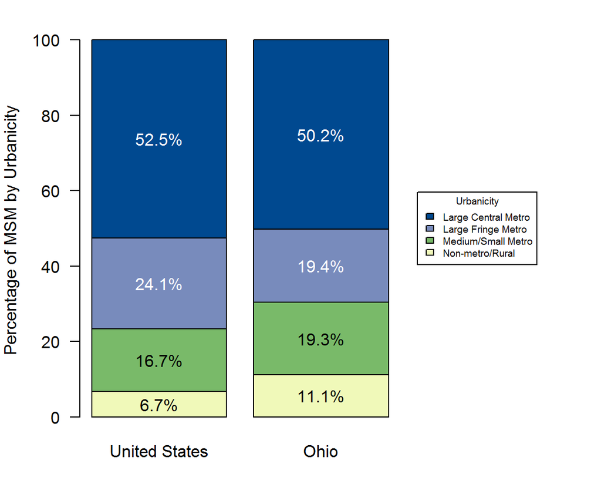

### MSM in Ohio Counties

Among counties or county-equivalent areas in Ohio, Franklin County had the largest population of MSM at 31,220, representing 21.6% of all MSM in the state. Franklin County also had the highest percentage of MSM among adult men in Ohio at 7.2%. This was greater than the percentage for Ohio as a whole, which was 3.4% of adult men.

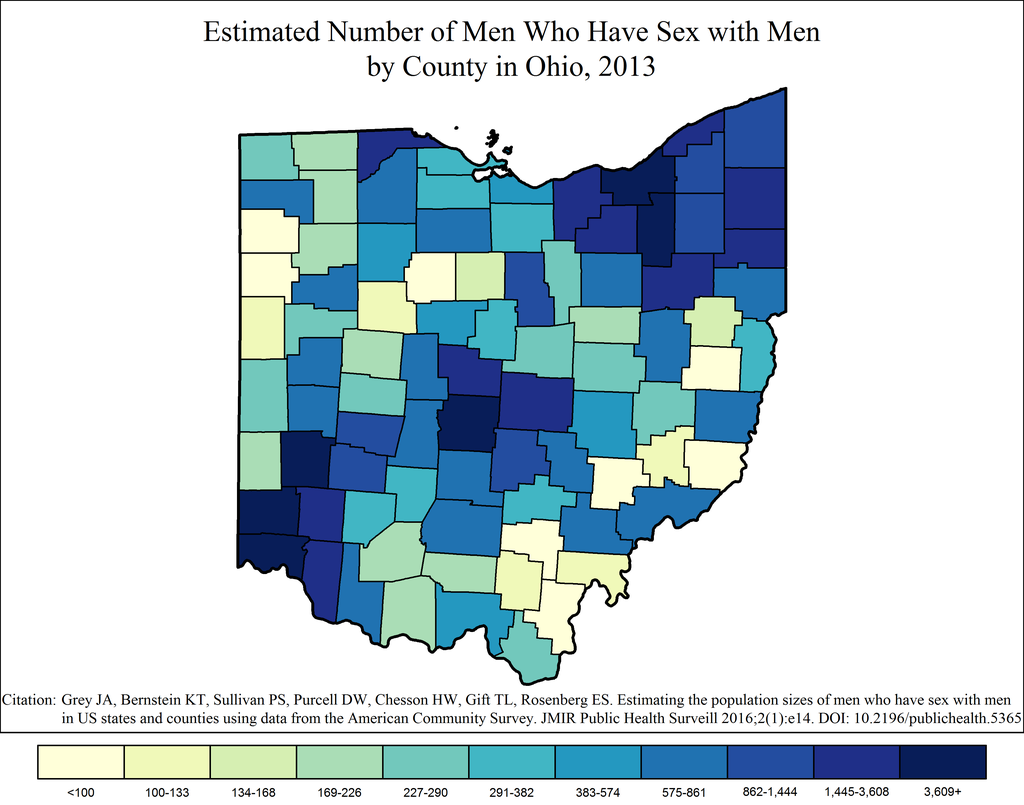

Note: Range cutpoints for the map are based on the distribution of MSM among all counties in the United States.

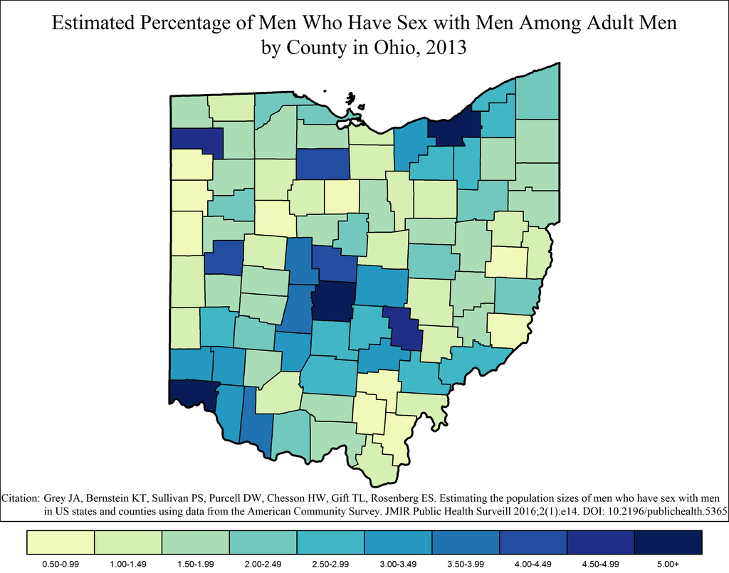

### MSM in Ohio Metropolitan Statistical Areas

#### Columbus Metropolitan Statistical Area

The Columbus MSA had the largest metropolitan population of MSM in Ohio at 40,536, or 28.1% of all MSM in the state. Of the 704,527 adult men in Columbus, an estimated 5.8% were MSM.

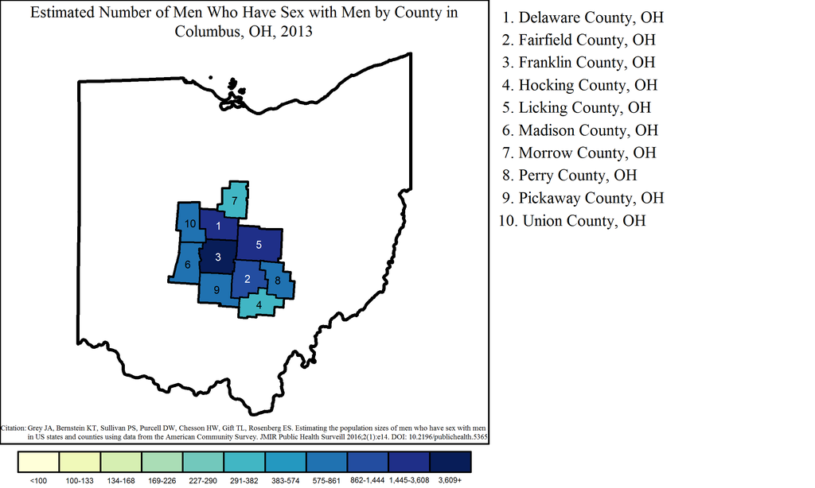

Note: Range cutpoints for the map are based on the distribution of MSM among all counties in the United States.

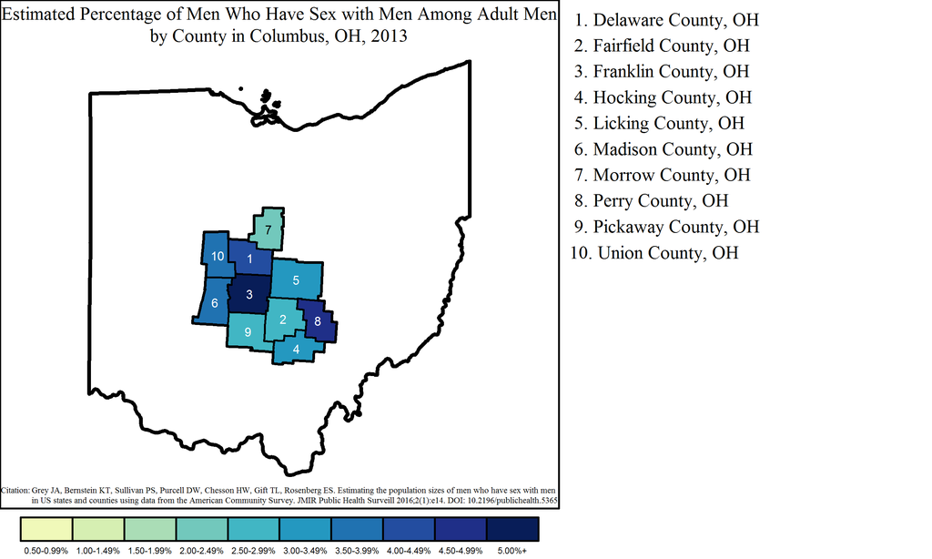

#### Cleveland-Elyria Metropolitan Statistical Area

The Cleveland-Elyria MSA had a population of 34,650 MSM, or 24.0% of all MSM in Ohio. Of the 755,993 adult men in Cleveland-Elyria, an estimated 4.6% were MSM.

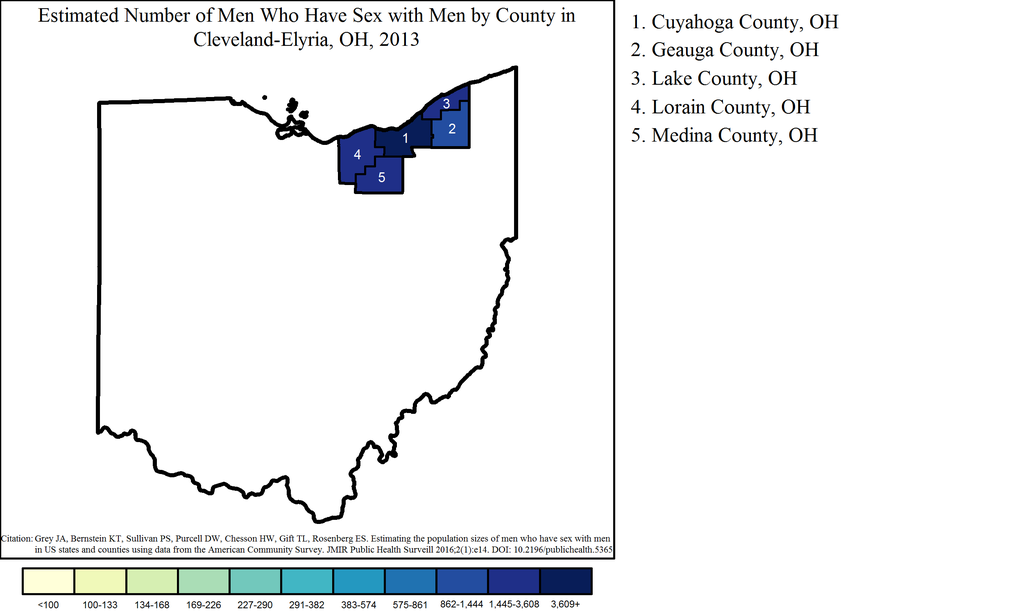

Note: Range cutpoints for the map are based on the distribution of MSM among all counties in the United States.

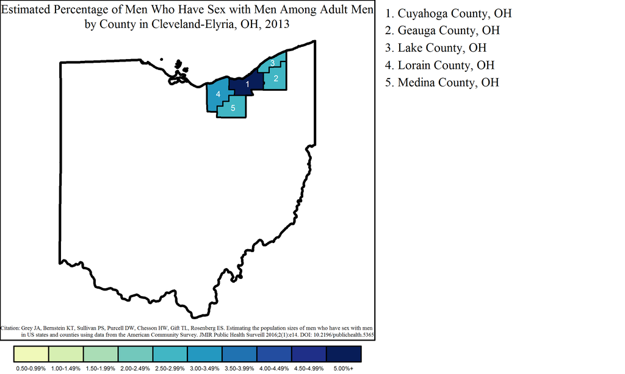

#### Cincinnati Metropolitan Statistical Area

The Cincinnati MSA overlaps three states: Indiana, Kentucky and Ohio. The Ohio portion of the MSA had 25,251 MSM, or 17.5% of all MSM in the state and 79.5% of the 31,781 MSM in the MSA. Of 591,182 adult men in the Ohio part of Cincinnati, 4.3% were MSM. This was greater than the overall percentage of MSM among adult men in the MSA, which was 4.1% of adult men (31,781 out of 770,623).

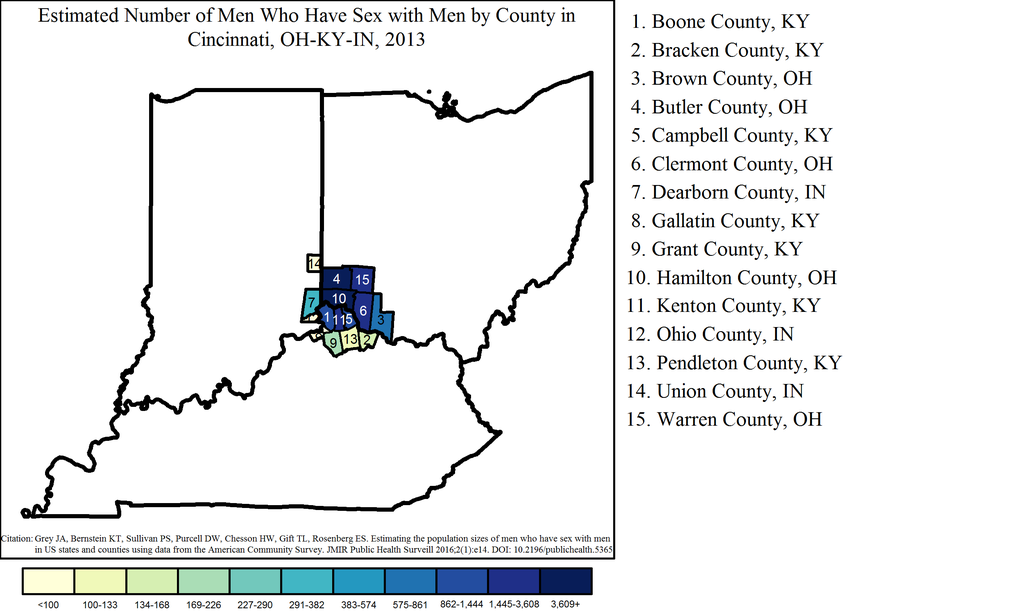

Note: Range cutpoints for the map are based on the distribution of MSM among all counties in the United States.

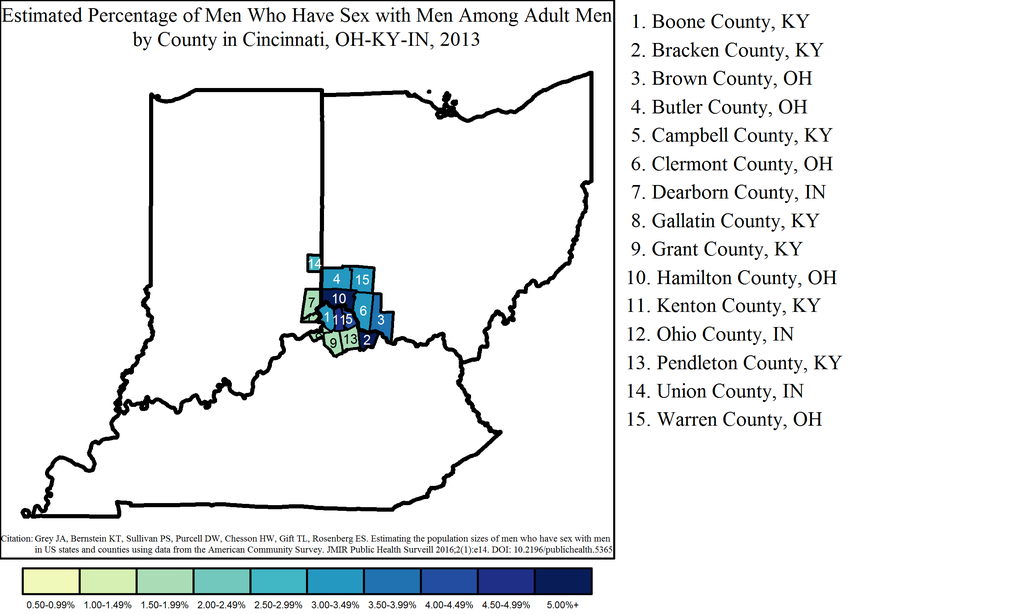

#### Dayton Metropolitan Statistical Area

The Dayton MSA had a population of 6,886 MSM, or 4.8% of all MSM in Ohio. Of the 295,376 adult men in Dayton, an estimated 2.3% were MSM.

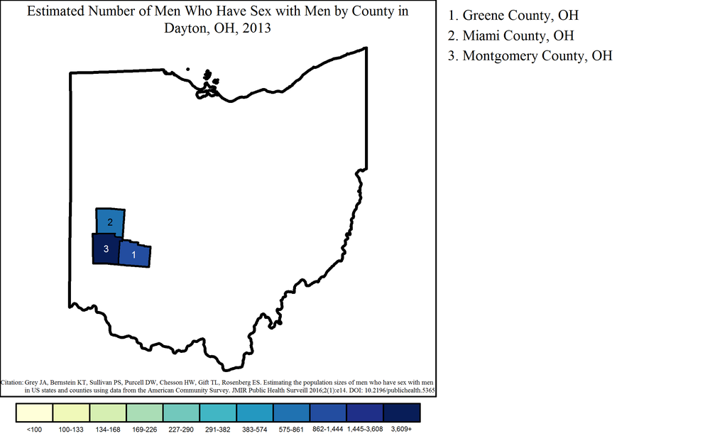

Note: Range cutpoints for the map are based on the distribution of MSM among all counties in the United States.

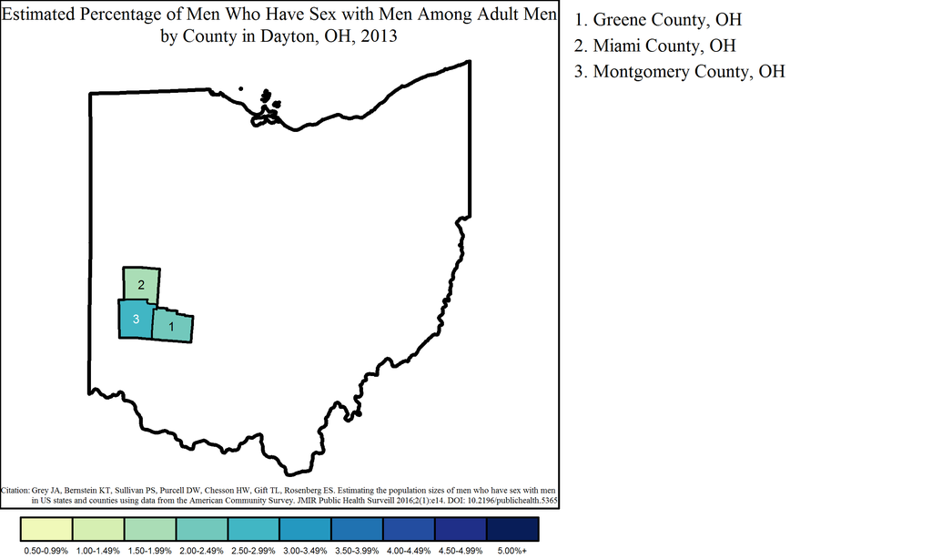

#### Akron Metropolitan Statistical Area

The Akron MSA had a population of 6,240 MSM, or 4.3% of all MSM in Ohio. Of the 262,926 adult men in Akron, an estimated 2.4% were MSM.

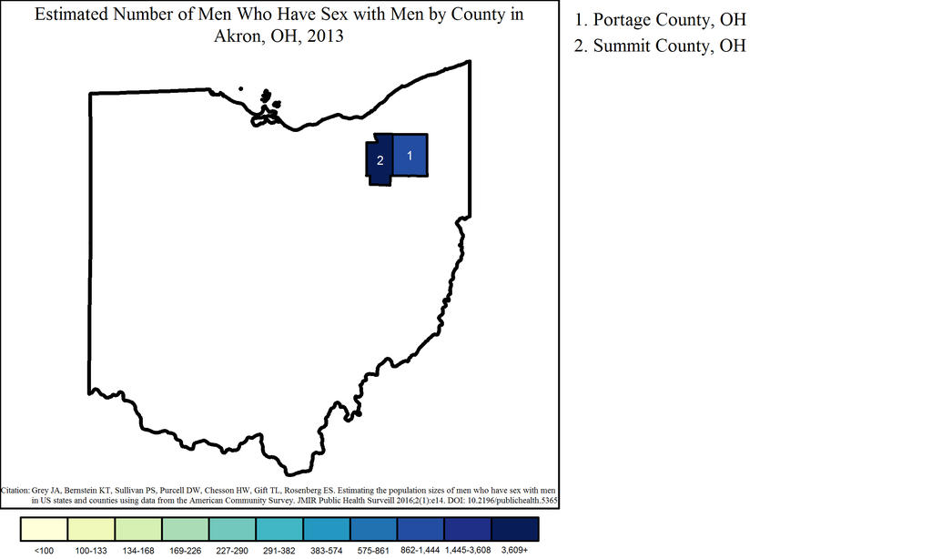

Note: Range cutpoints for the map are based on the distribution of MSM among all counties in the United States.

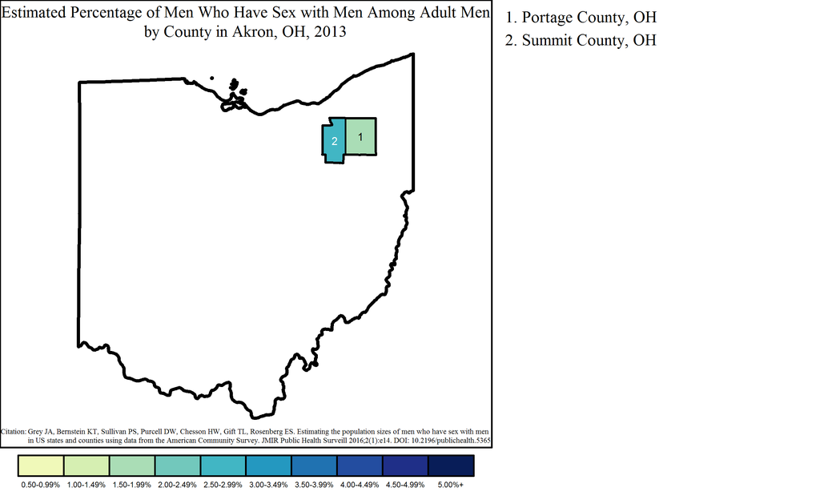

#### Toledo Metropolitan Statistical Area

The Toledo MSA had a population of 4,261 MSM, or 3.0% of all MSM in Ohio. Of the 223,547 adult men in Toledo, an estimated 1.9% were MSM.

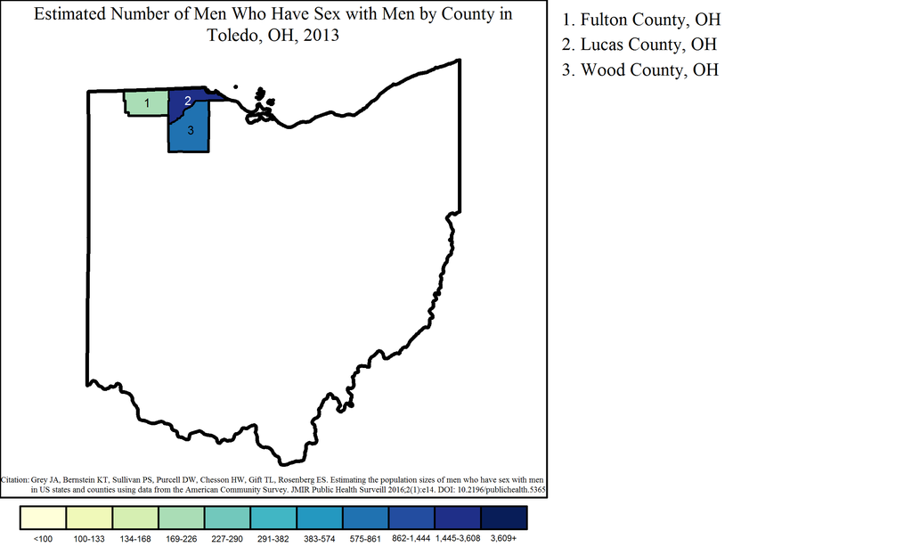

Note: Range cutpoints for the map are based on the distribution of MSM among all counties in the United States.

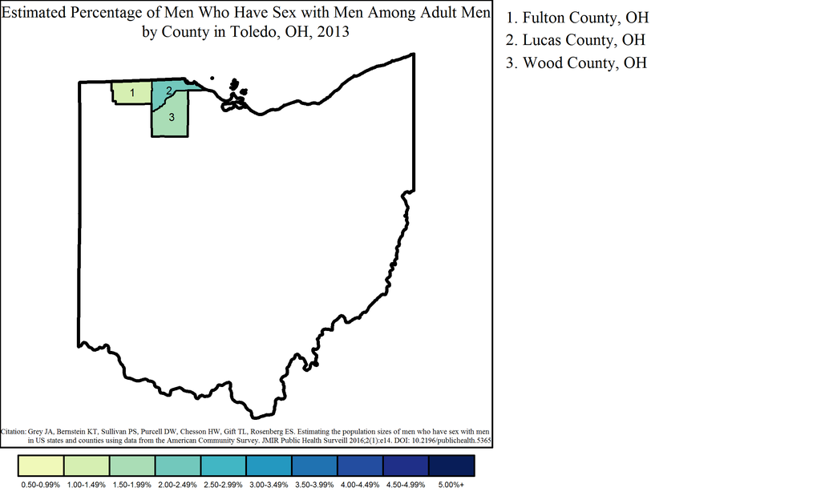

#### Canton-Massillon Metropolitan Statistical Area

The Canton-Massillon MSA had a population of 3,431 MSM, or 2.4% of all MSM in Ohio. Of the 149,296 adult men in Canton-Massillon, an estimated 2.3% were MSM.

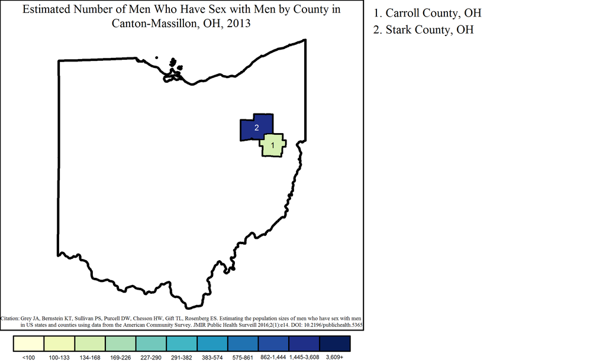

Note: Range cutpoints for the map are based on the distribution of MSM among all counties in the United States.

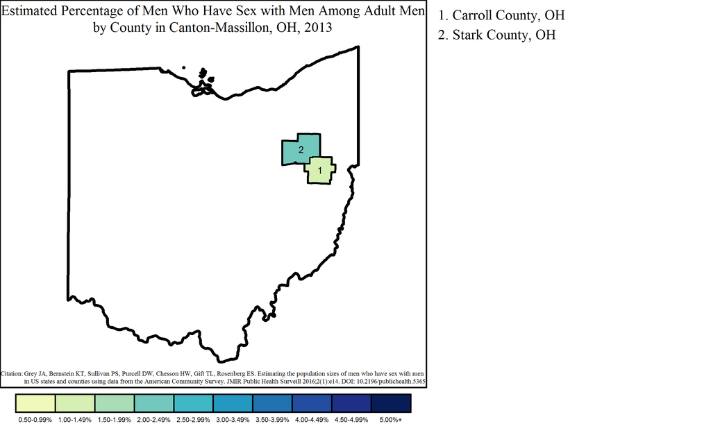

#### Youngstown-Warren-Boardman Metropolitan Statistical Area

The Youngstown-Warren-Boardman MSA overlaps two states: Ohio and Pennsylvania. The Ohio portion of the MSA had 3,025 MSM, or 2.1% of all MSM in the state and 83.3% of the 3,631 MSM in the MSA. Of 167,364 adult men in the Ohio part of Youngstown-Warren-Boardman, 1.8% were MSM. This was greater than the overall percentage of MSM among adult men in the MSA, which was 1.7% of adult men (3,631 out of 211,654).

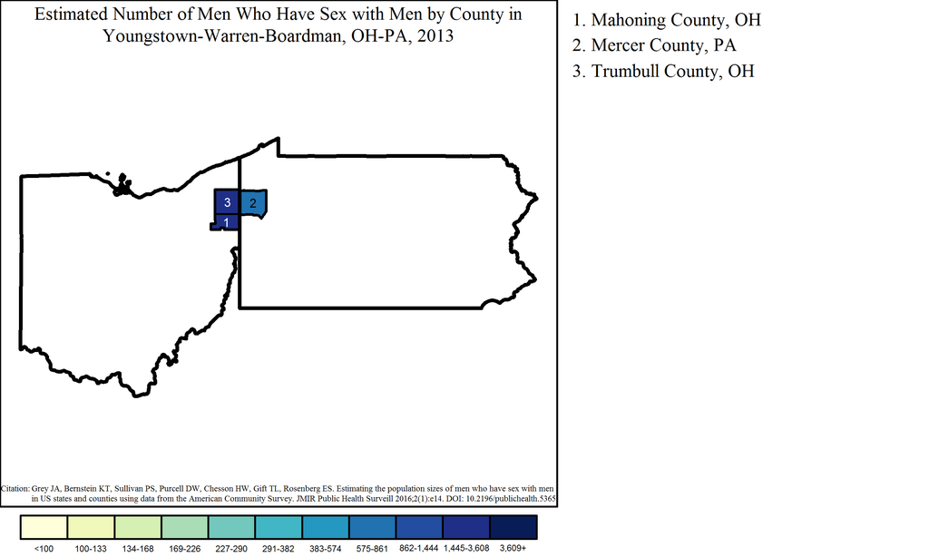

Note: Range cutpoints for the map are based on the distribution of MSM among all counties in the United States.

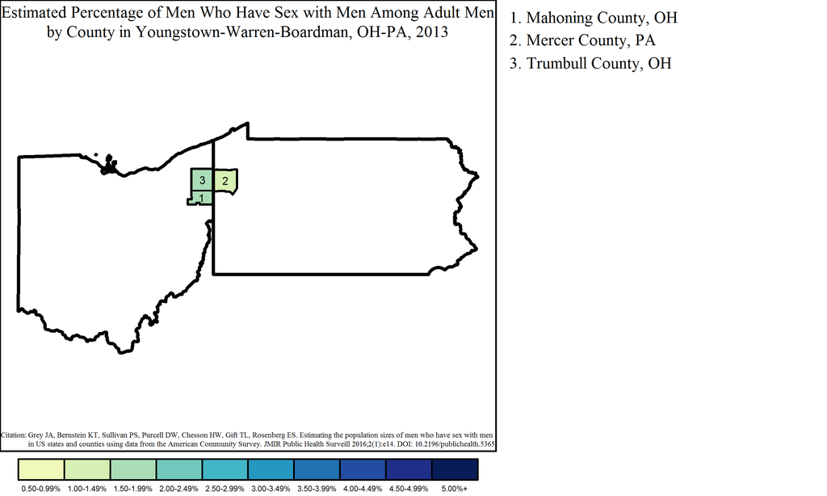

#### Springfield Metropolitan Statistical Area

The Springfield MSA had a population of 993 MSM, or 0.7% of all MSM in Ohio. Of the 50,241 adult men in Springfield, an estimated 2.0% were MSM.

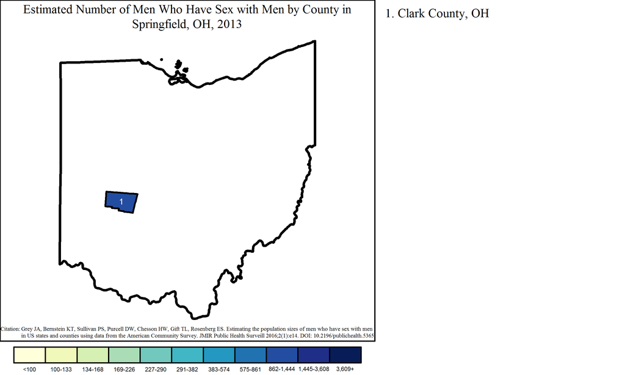

Note: Range cutpoints for the map are based on the distribution of MSM among all counties in the United States.

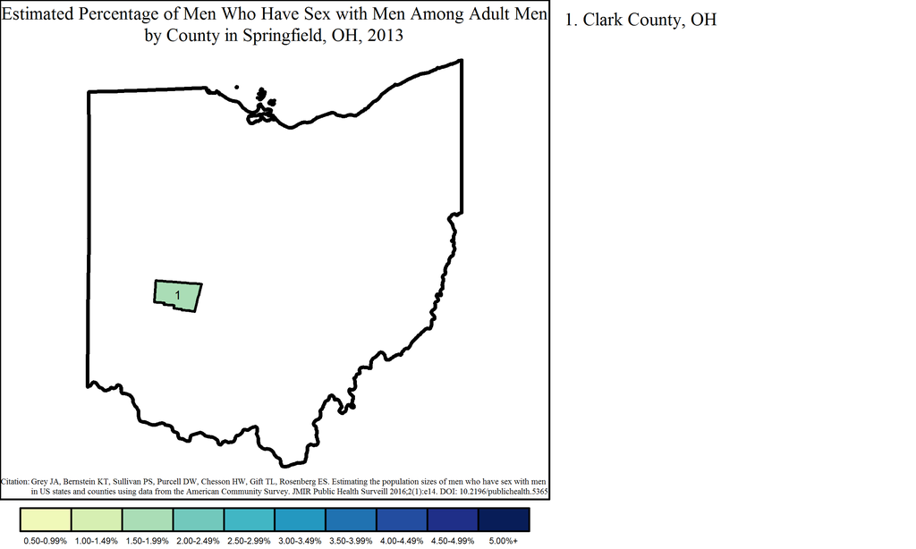

#### Mansfield Metropolitan Statistical Area

The Mansfield MSA had a population of 964 MSM, or 0.7% of all MSM in Ohio. Of the 48,428 adult men in Mansfield, an estimated 2.0% were MSM.

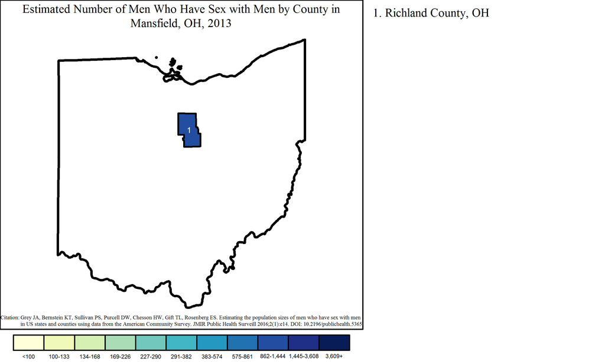

Note: Range cutpoints for the map are based on the distribution of MSM among all counties in the United States.

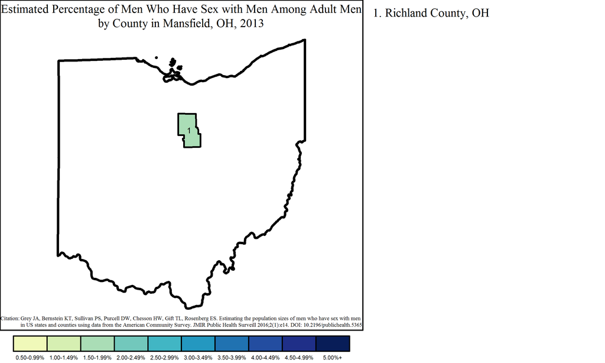

#### Lima Metropolitan Statistical Area

The Lima MSA had a population of 820 MSM, or 0.6% of all MSM in Ohio. Of the 40,456 adult men in Lima, an estimated 2.0% were MSM.

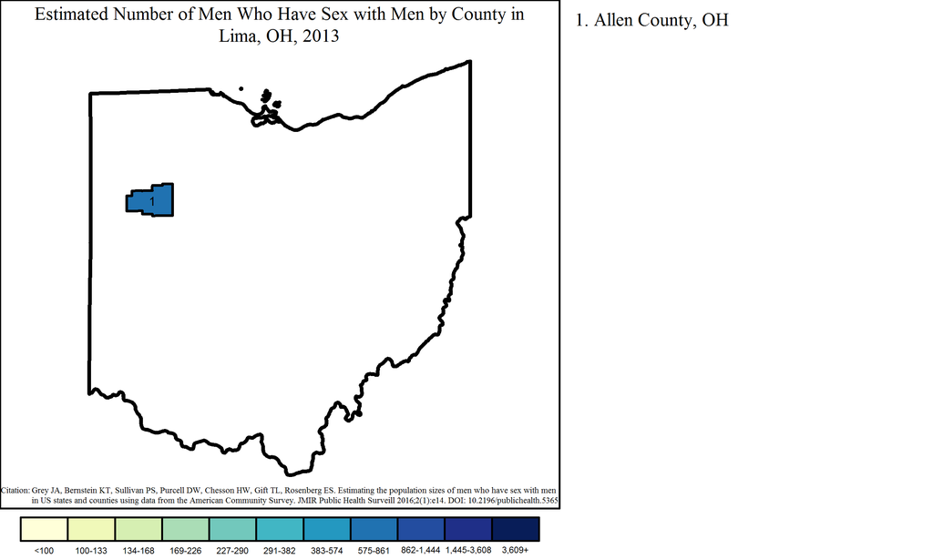

Note: Range cutpoints for the map are based on the distribution of MSM among all counties in the United States.

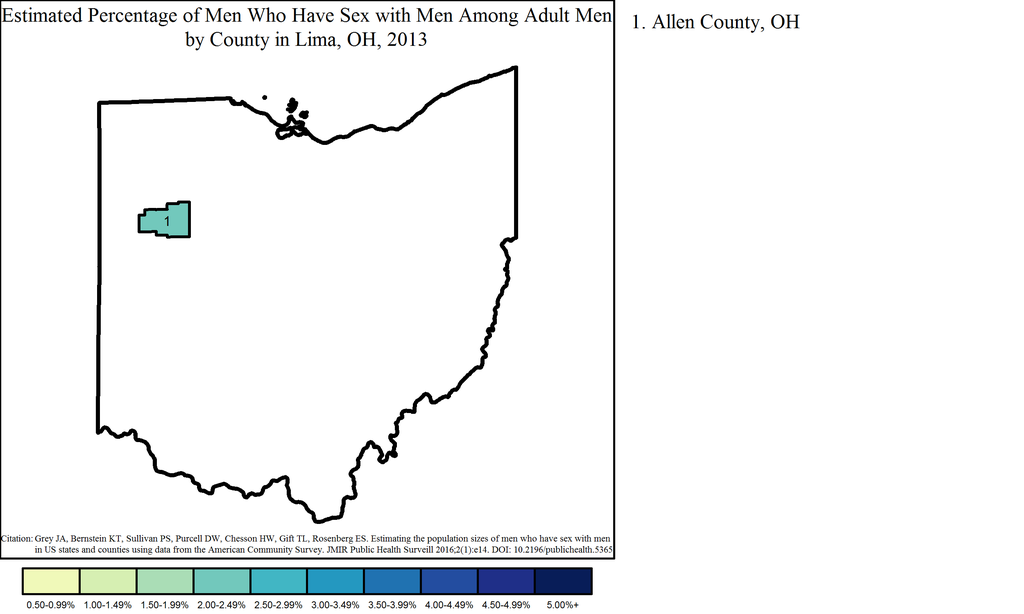

#### Wheeling Metropolitan Statistical Area

The Wheeling MSA overlaps two states: Ohio and West Virginia. The Ohio portion of the MSA had 625 MSM, or 0.4% of all MSM in the state and 62.3% of the 1,004 MSM in the MSA. Of 28,509 adult men in the Ohio part of Wheeling, 2.2% were MSM. This was greater than the overall percentage of MSM among adult men in the MSA, which was 1.7% of adult men (1,004 out of 57,795).

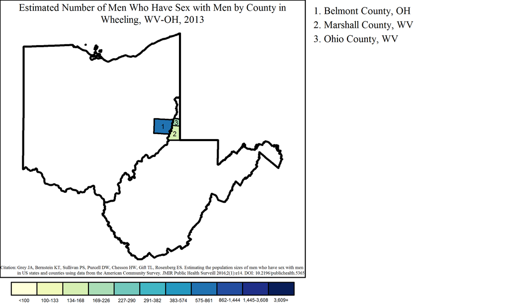

Note: Range cutpoints for the map are based on the distribution of MSM among all counties in the United States.

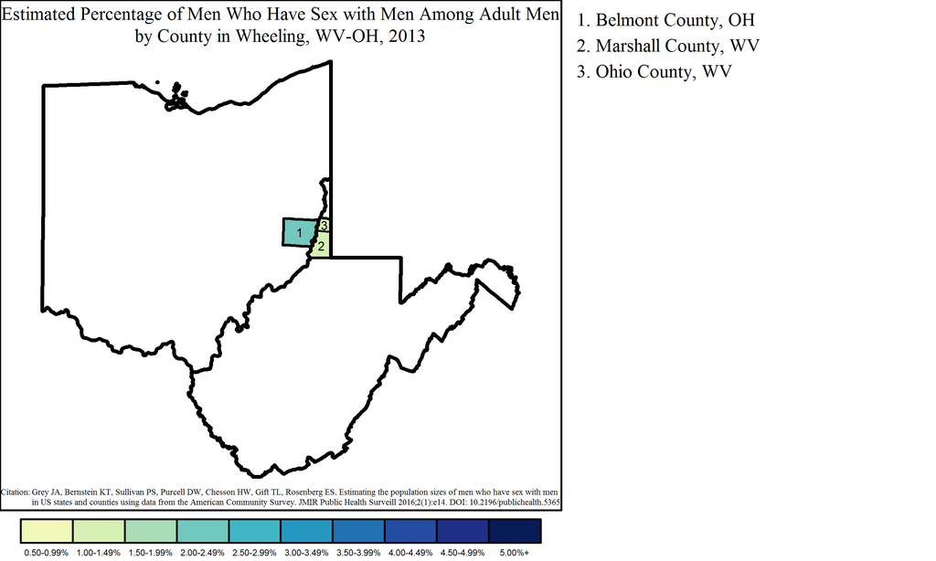

#### Weirton-Steubenville Metropolitan Statistical Area

The Weirton-Steubenville MSA overlaps two states: Ohio and West Virginia. The Ohio portion of the MSA had 369 MSM, or 0.3% of all MSM in the state and 49.2% of the 750 MSM in the MSA. Of 26,244 adult men in the Ohio part of Weirton-Steubenville, 1.4% were MSM. This was less than the overall percentage of MSM among adult men in the MSA, which was 1.6% of adult men (750 out of 47,204).

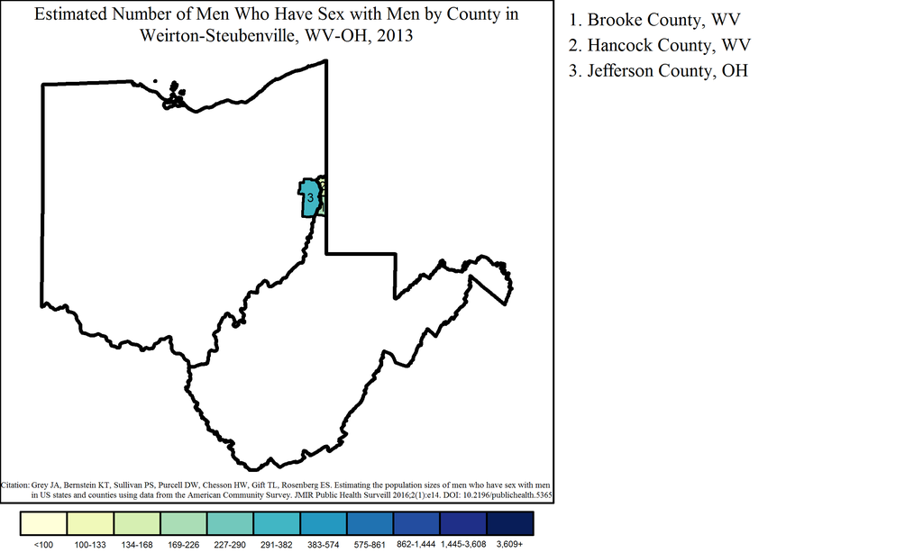

Note: Range cutpoints for the map are based on the distribution of MSM among all counties in the United States.

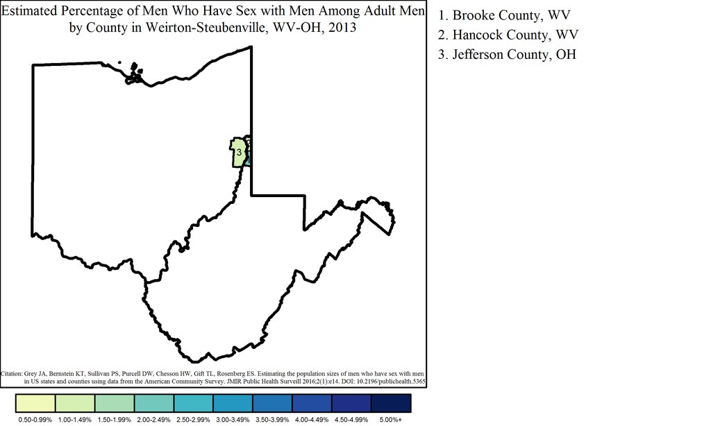

#### Huntington-Ashland Metropolitan Statistical Area

The Huntington-Ashland MSA overlaps three states: Kentucky, Ohio and West Virginia. The Ohio portion of the MSA had 246 MSM, or 0.2% of all MSM in the state and 9.6% of the 2,571 MSM in the MSA. Of 22,718 adult men in the Ohio part of Huntington-Ashland, 1.1% were MSM. This was less than the overall percentage of MSM among adult men in the MSA, which was 1.9% of adult men (2,571 out of 137,392).

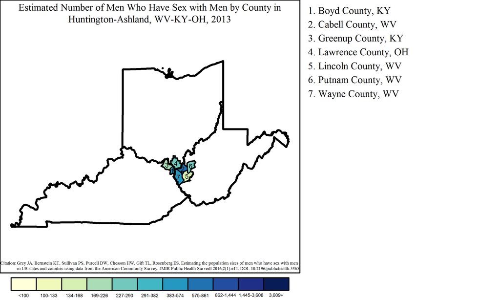

Note: Range cutpoints for the map are based on the distribution of MSM among all counties in the United States.

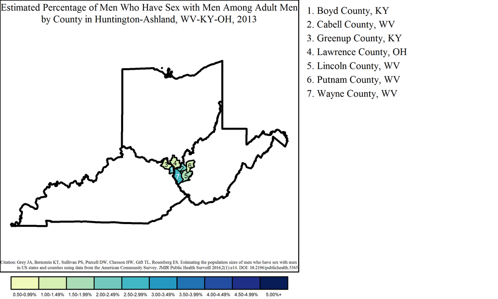